### About the data:

I got the screen time from the iPhone Screen Time tool, which automatically tracks how long you use your phone each day. I kept track of this from 7/19/2019 to 9/29/2019, with a two week gap from 8/10 to 8/26 (I was on vacation with limited cell service, so I figured that this would result in a lot more variability than usual). Some days, I kept my phone in grayscale display mode (which you can change in your settings). I then plotted the amount of time I use my phone (in minutes), coloring by whether or not my phone was in grayscale.

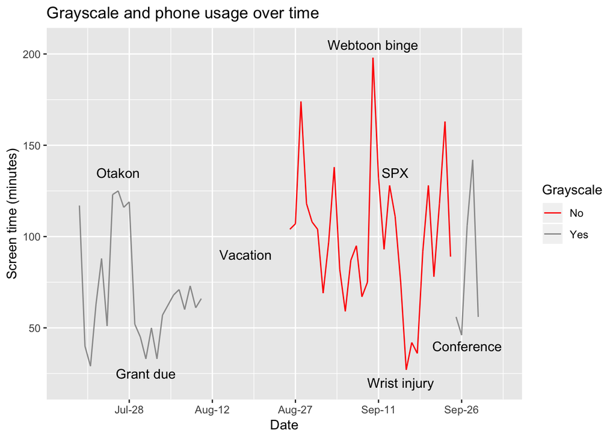

### Plot grayscale vs. no grayscale

Boxplots of screen time usage based on grayscale vs. no grayscale. Seems like I use my phone less when it’s in grayscale, which makes sense. It’s a significant difference, with grayscale having an estimated effect size of about thirty fewer minutes of screen time.

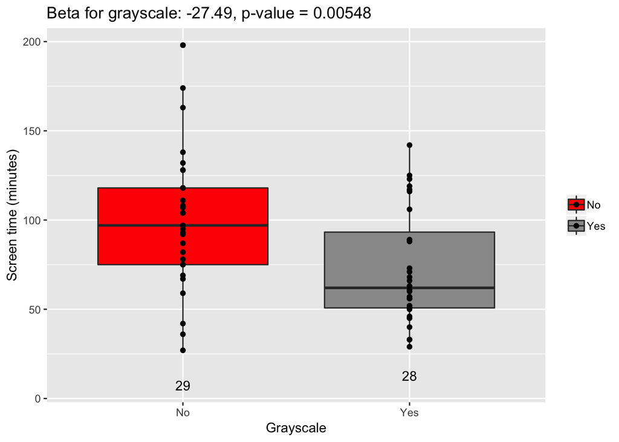

```r
give.n <- function(x){return(c(y = min(x)-(sd(x)/2), label = length(x)))}
gscale <- ggplot(df, aes(Grayscale, Screen.time, fill = Grayscale)) + geom_boxplot( ) + stat_summary(fun.data = give.n, geom = "text") + geom_point() + ggtitle('Beta for grayscale: -27.49, p-value = 0.00548') + xlab('Grayscale') + ylab('Screen time (minutes)') + scale_fill_manual(values=c("#FF0000", "#999999")) + theme(legend.title = element_blank())
print(gscale)
```

```r
lm(df$Screen.time ~ df$Grayscale) %>% summary
```

```
##
## Call:
## lm(formula = df$Screen.time ~ df$Grayscale)
##
## Residuals:
##     Min      1Q  Median      3Q     Max
## -73.172 -22.679  -6.679  17.828  97.828
##
## Coefficients:
##                 Estimate Std. Error t value Pr(>|t|)
## (Intercept)      100.172      6.664  15.031  < 2e-16 ***
## df$GrayscaleYes  -27.494      9.509  -2.891  0.00548 **
## ---
## Signif. codes:  0 '***' 0.001 '**' 0.01 '*' 0.05 '.' 0.1 ' ' 1
##
## Residual standard error: 35.89 on 55 degrees of freedom
## Multiple R-squared:  0.1319, Adjusted R-squared:  0.1162
## F-statistic:  8.36 on 1 and 55 DF,  p-value: 0.005482
```

### Omit special days

There are certain events that resulted in me using my phone a lot more than usual - does this result still hold up if I omit those days? It appears like it does, and the effect size is actually larger now.

```r
no.specials <- subset(df, Wrist.Injury == 'No')
no.specials <- subset(no.specials, Special.Event == '')

lm(no.specials$Screen.time ~ no.specials$Grayscale) %>% summary
```

```
##
## Call:
## lm(formula = no.specials$Screen.time ~ no.specials$Grayscale)
##
## Residuals:
##    Min     1Q Median     3Q    Max
## -46.04 -19.75  -7.45  15.05  68.96
##
## Coefficients:
##                          Estimate Std. Error t value Pr(>|t|)
## (Intercept)               105.043      6.244  16.824  < 2e-16 ***
## no.specials$GrayscaleYes  -31.593      9.155  -3.451  0.00131 **
## ---
## Signif. codes:  0 '***' 0.001 '**' 0.01 '*' 0.05 '.' 0.1 ' ' 1
##
## Residual standard error: 29.94 on 41 degrees of freedom
## Multiple R-squared:  0.2251, Adjusted R-squared:  0.2062
## F-statistic: 11.91 on 1 and 41 DF,  p-value: 0.001308
```

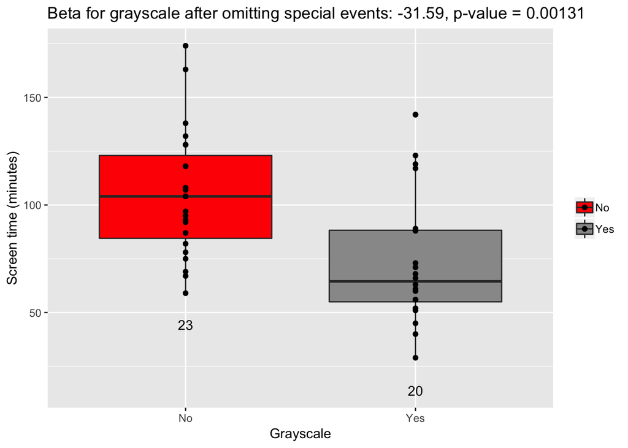

```r
no.special <- ggplot(no.specials, aes(Grayscale, Screen.time, fill = Grayscale)) + geom_boxplot( ) + stat_summary(fun.data = give.n, geom = "text") + geom_point() + ggtitle('Beta for grayscale after omitting special events: -31.59, p-value = 0.00131') + xlab('Grayscale') + ylab('Screen time (minutes)')  + scale_fill_manual(values=c("#FF0000", "#999999")) + theme(legend.title = element_blank())
print(no.special)
```

### pic for reddit:

```r
# library(gridExtra)
# # grid.arrange(w.title, gscale, ncol = 1)
# png(file = '~/Desktop/for.reddit.png', height = 600, width = 600)
# grid.arrange(w.title, d.of.week, ncol = 1)
# dev.off()

png(file = '~/Desktop/for.reddit2.png', height = 500, width = 1000)
print(w.title)
dev.off()
```